# RR_presentation

2024-05-30

Load the libraries in a reproducible way.

```r
# Libraries
if (!require(dplyr)) {install.packages("dplyr"); library(dplyr)}
if (!require(ggplot2)) {install.packages("ggplot2"); library(ggplot2)}
if (!require(plm)) {install.packages("plm"); library(plm)}
if (!require(zoo)) {install.packages("zoo"); library(zoo)}
if (!require(lmtest)) {install.packages("lmtest"); library(lmtest)}
```

```r
# Read the data
data <- read.csv(file = "preprocessed_data.csv")
data <- data %>% select(-X)

# Check the structure
str(data)
```

```
## 'data.frame':    624 obs. of  14 variables:
##  $ year_month     : int  201801 201802 201803 201804 201805 201806 201807 201808 201809 201810 ...
##  $ time           : int  1 2 3 4 5 6 7 8 9 10 ...
##  $ country        : chr  "United States" "United States" "United States" "United States" ...
##  $ sky            : num  0.301 0.464 0.413 0.43 0.446 ...
##  $ temperature    : num  31.7 40.2 38.7 46.9 62.3 ...
##  $ streams        : num  2.28e+09 2.20e+09 2.51e+09 2.70e+09 2.66e+09 ...
##  $ af_danceability: num  0.712 0.712 0.717 0.712 0.709 ...
##  $ af_energy      : num  0.616 0.616 0.62 0.629 0.63 ...
##  $ af_key         : num  5.58 5.61 5.57 5.59 5.55 ...
##  $ af_loudness    : num  -6.36 -6.4 -6.39 -6.35 -6.28 ...
##  $ af_speechiness : num  0.132 0.133 0.133 0.139 0.139 ...
##  $ af_acousticness: num  0.17 0.171 0.174 0.179 0.195 ...
##  $ af_valence     : num  0.45 0.452 0.457 0.451 0.444 ...
##  $ af_tempo       : num  121 121 121 123 124 ...
```

We perform Exploratory Data Analysis to get to know the data.

```r
# Summary statistics
data %>%
  select(-c(year_month, time)) %>%
  group_by(country) %>%
  summarize(mean_sky = mean(sky),
            mean_temperature = mean(temperature),
            sum_streams = sum(streams)) %>%
  arrange(desc(sum_streams))
```

```
## # A tibble: 26 × 4
##    country        mean_sky mean_temperature sum_streams
##    <chr>             <dbl>            <dbl>       <dbl>
##  1 United States     0.371             54.7 60578527960
##  2 Germany           0.277             53.8 16773548342
##  3 Mexico            0.361             64.2 16508390128
##  4 United Kingdom    0.579             53.6 15456909759
##  5 Italy             0.303             62.1 11248620606
##  6 Spain             0.318             59.6 10403806608
##  7 France            0.425             54.9  9555950595
##  8 Canada            0.461             47.9  8036952361
##  9 Netherlands       0.266             52.6  7998555668
## 10 Sweden            0.608             45.2  6047254377
## # ℹ 16 more rows
```

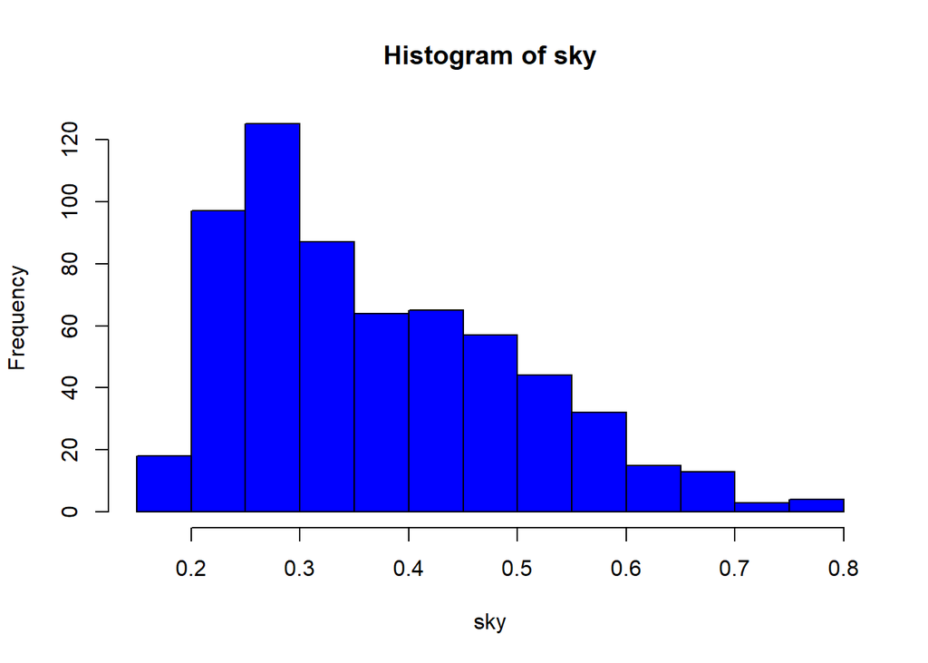

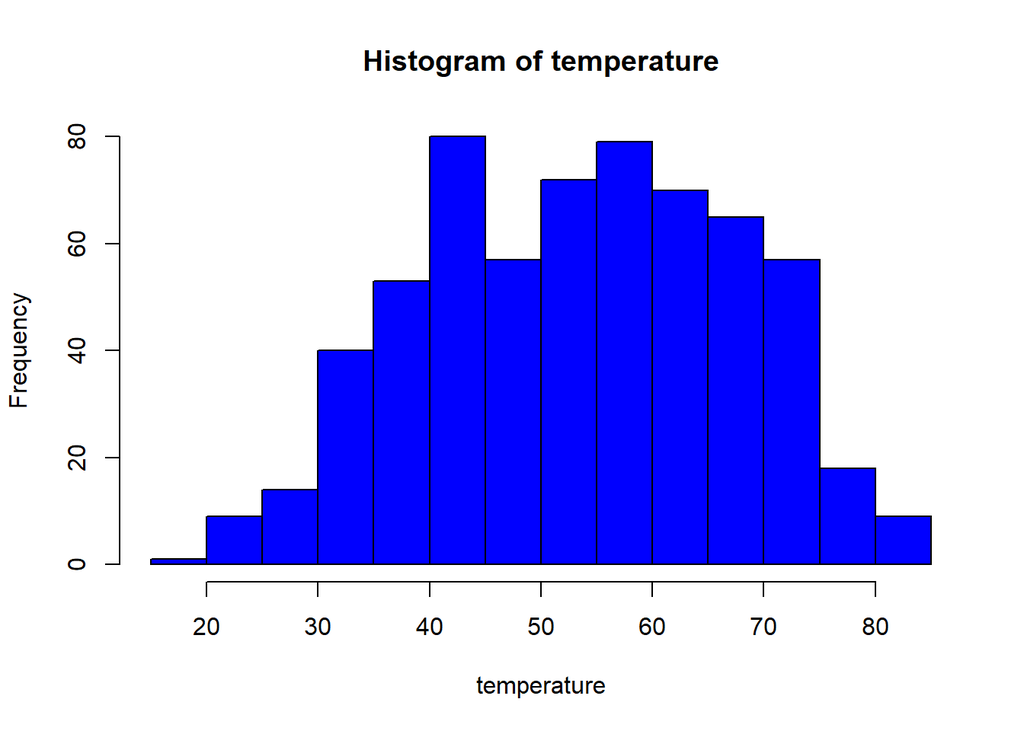

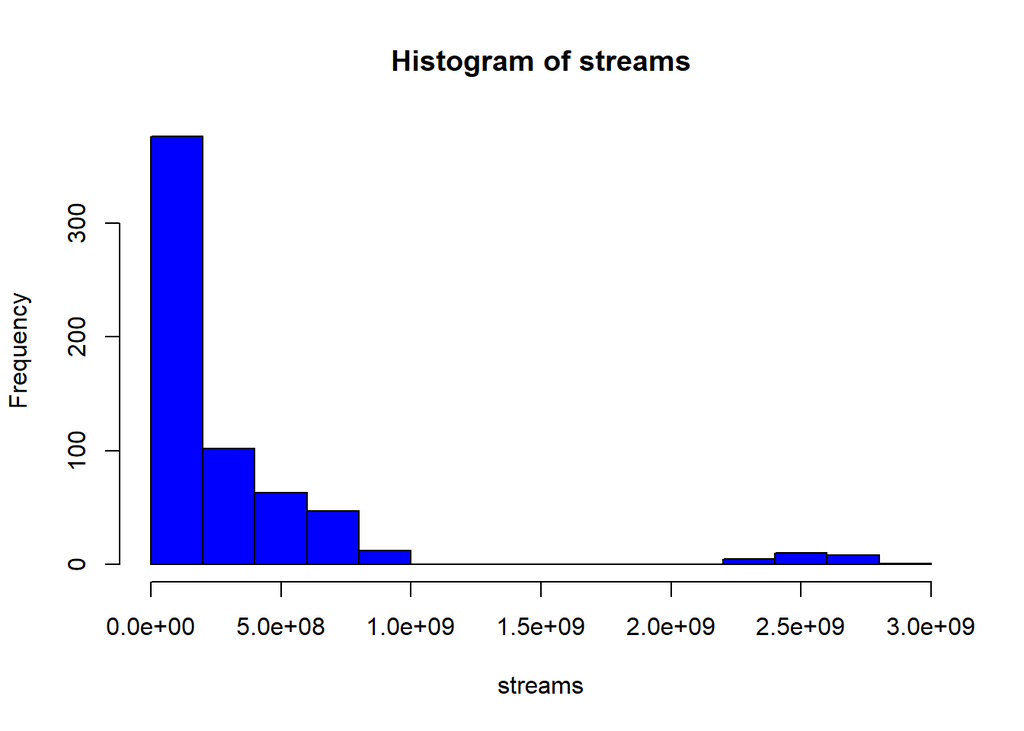

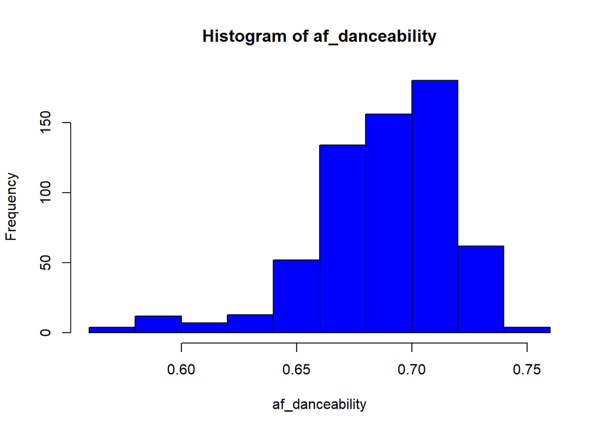

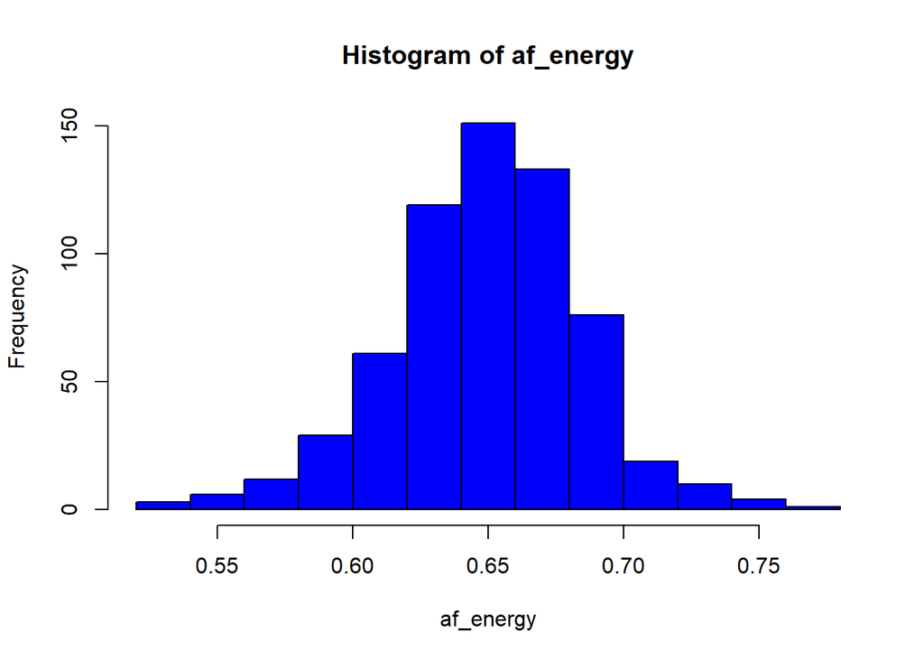

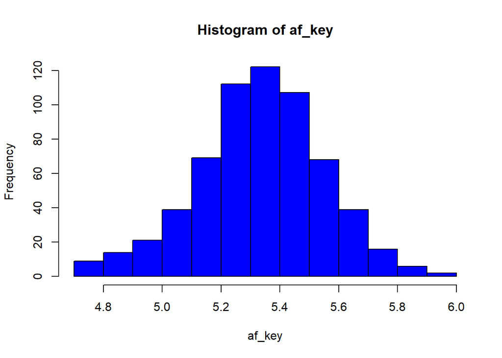

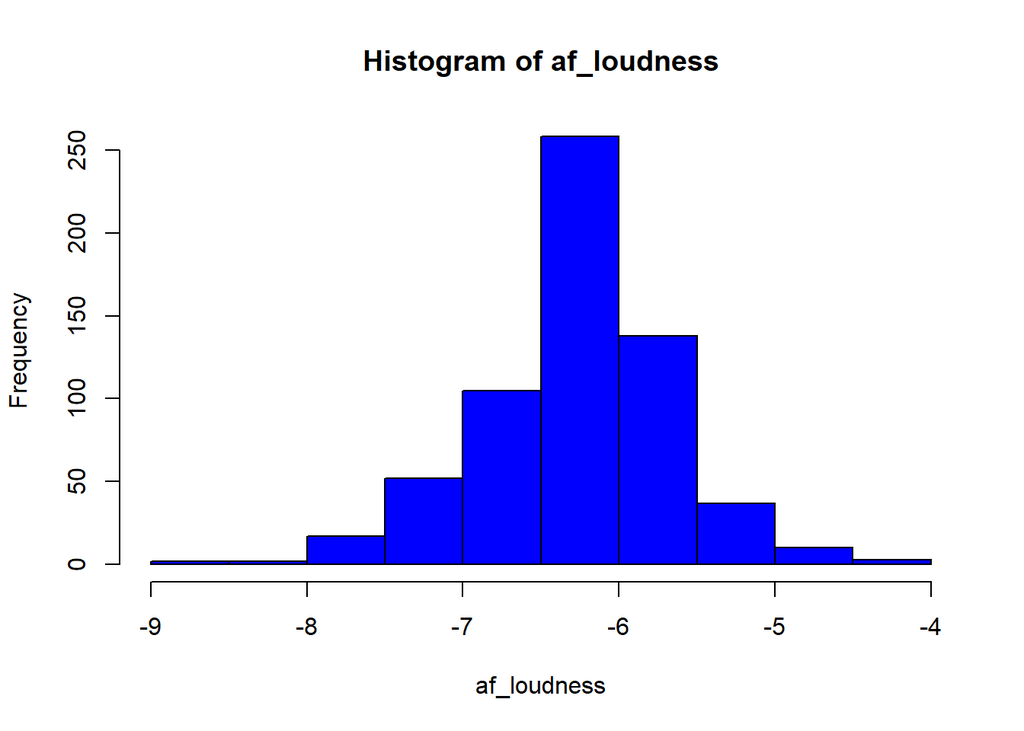

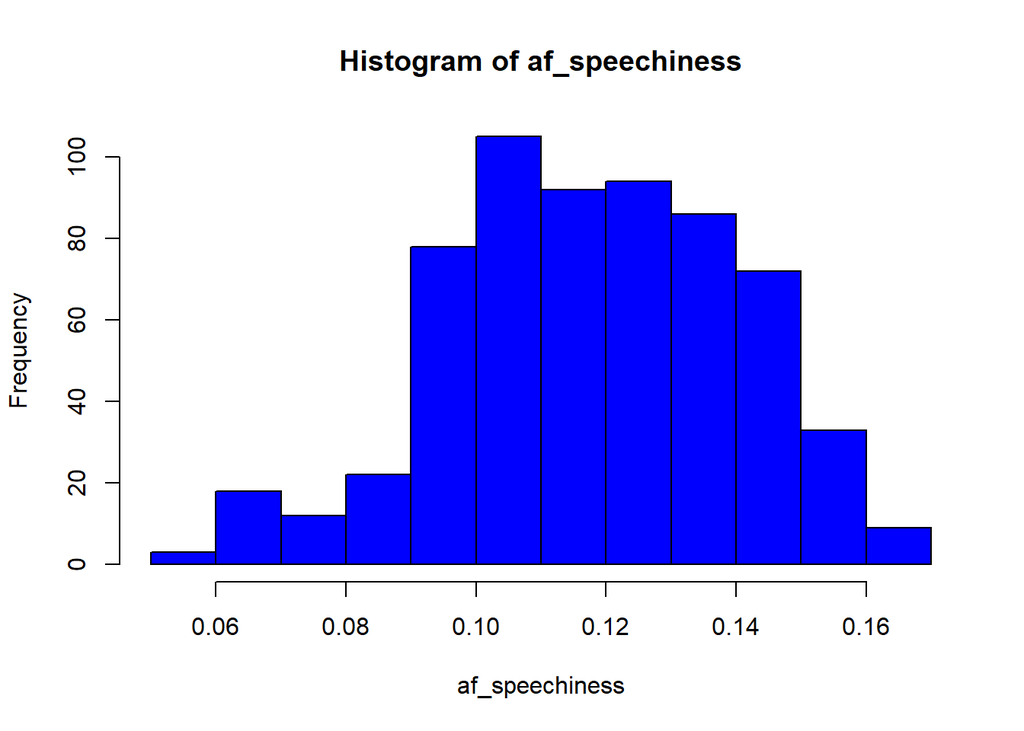

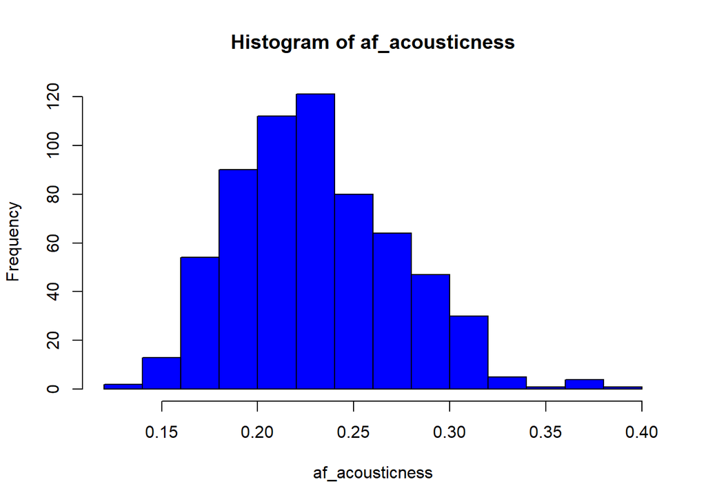

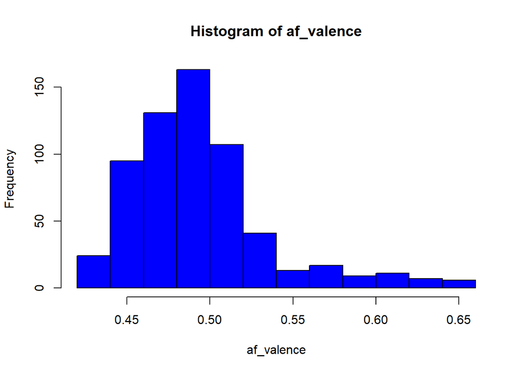

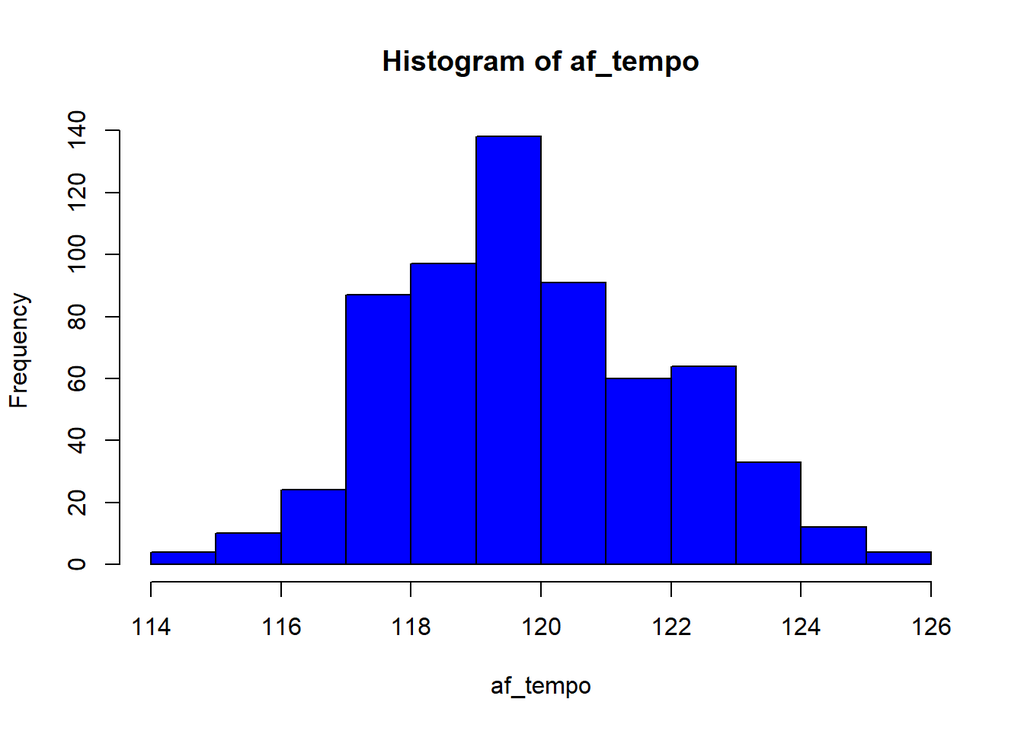

```r
# Check the distribution of variables

# Write a function "plot_histogram" to plot the distribution of every numeric variable

plot_histograms <- function(data) {

  numeric_cols <- sapply(data, is.numeric)
  data_numeric <- data[, numeric_cols] %>% select(-c('time', 'year_month'))

  for (col in colnames(data_numeric)) {
    hist(data_numeric[[col]], main = paste("Histogram of", col), xlab = col, ylab = "Frequency", col = "blue", border = "black")
  }
}


plot_histograms(data)
```

Based on the distribution of the variables we apply the logarithmic transformation to symmetrize the distribution.

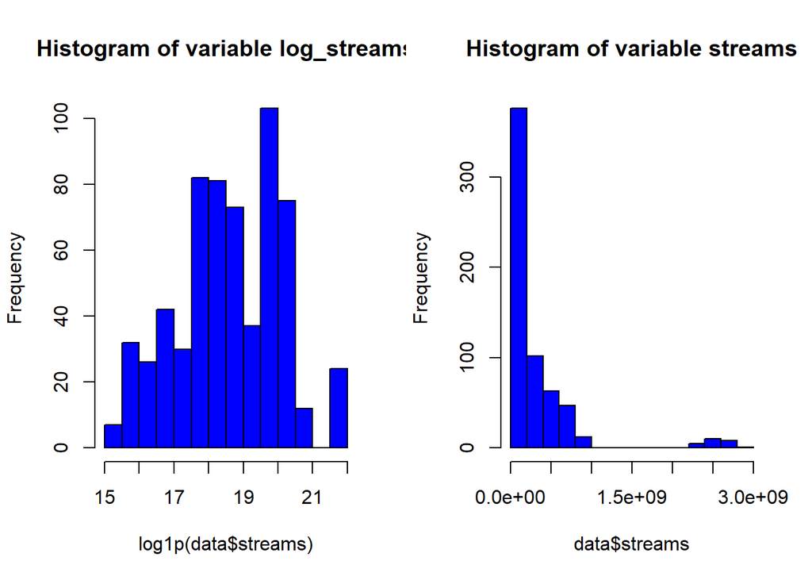

```r
# Feature engineering

# Apply log(x + 1) transformation for variables with highly non symmetric distribution
par(mfrow = c(1,2))
hist(log1p(data$streams), main = "Histogram of variable log_streams", col = "blue", border = "black")
hist(data$streams, main = "Histogram of variable streams", col = "blue", border = "black")
```

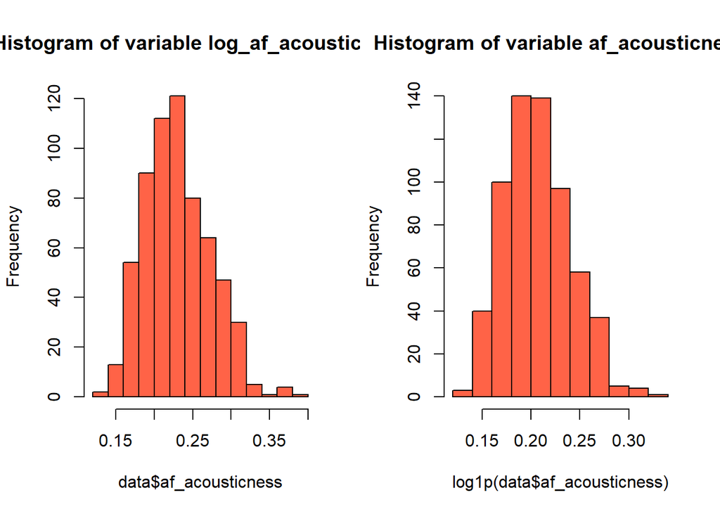

```r
par(mfrow = c(1,1))

data$log_streams <- log1p(data$streams)

par(mfrow = c(1,2))
hist(data$af_acousticness, main = "Histogram of variable log_af_acousticness",
     col = "tomato", border = "black")
hist(log1p(data$af_acousticness), main = "Histogram of variable af_acousticness",
     col = "tomato", border = "black")
```

```r
par(mfrow = c(1,1))

data$log_af_acousticness <- log1p(data$af_acousticness)
```

Initially we will calculate Fixed Effects Model, Random Effects Model and simple Pooled Regression. Then we will decide which model is most appropriate regarding to the data we have.

```r
# Modelling

# Fixed Effects Model
model.fixed <- plm(af_valence ~ sky + temperature + log_streams +
                     af_danceability + af_energy + af_key +
                     af_loudness + af_speechiness + af_acousticness +
                     af_tempo, data = data, index = c("country", "year_month"),
                   model = "within")

summary(model.fixed)
```

```
## Oneway (individual) effect Within Model
##
## Call:
## plm(formula = af_valence ~ sky + temperature + log_streams +
##     af_danceability + af_energy + af_key + af_loudness + af_speechiness +
##     af_acousticness + af_tempo, data = data, model = "within",
##     index = c("country", "year_month"))
##
## Balanced Panel: n = 26, T = 24, N = 624
##
## Residuals:
##       Min.    1st Qu.     Median    3rd Qu.       Max.
## -0.0434632 -0.0109447 -0.0010417  0.0106634  0.0559202
##
## Coefficients:
##                    Estimate  Std. Error t-value  Pr(>|t|)
## sky             -4.2710e-03  1.2164e-02 -0.3511  0.725614
## temperature      3.5835e-04  7.7896e-05  4.6004 5.169e-06 ***
## log_streams      1.6341e-02  4.4863e-03  3.6424  0.000294 ***
## af_danceability -1.9860e-01  7.3639e-02 -2.6969  0.007200 **
## af_energy        2.4493e-01  1.0841e-01  2.2593  0.024231 *
## af_key           1.5526e-03  4.1534e-03  0.3738  0.708671
## af_loudness      3.1016e-03  5.0806e-03  0.6105  0.541779
## af_speechiness   7.5150e-02  8.9118e-02  0.8433  0.399422
## af_acousticness  1.5533e-01  5.3685e-02  2.8934  0.003952 **
## af_tempo         1.3468e-03  4.6015e-04  2.9269  0.003556 **
## ---
## Signif. codes:  0 '***' 0.001 '**' 0.01 '*' 0.05 '.' 0.1 ' ' 1
##
## Total Sum of Squares:    0.19992
## Residual Sum of Squares: 0.15303
## R-Squared:      0.23457
## Adj. R-Squared: 0.18901
## F-statistic: 18.0196 on 10 and 588 DF, p-value: < 2.22e-16
```

```r
# Random Effects Model
model.random <- plm(af_valence ~ sky + temperature + log_streams +
                     af_danceability + af_energy + af_key +
                     af_loudness + af_speechiness + af_acousticness +
                     af_tempo, data = data, index = c("country", "year_month"),
                   model = "random")

summary(model.random)
```

```
## Oneway (individual) effect Random Effect Model
##    (Swamy-Arora's transformation)
##
## Call:
## plm(formula = af_valence ~ sky + temperature + log_streams +
##     af_danceability + af_energy + af_key + af_loudness + af_speechiness +
##     af_acousticness + af_tempo, data = data, model = "random",
##     index = c("country", "year_month"))
##
## Balanced Panel: n = 26, T = 24, N = 624
##
## Effects:
##                     var   std.dev share
## idiosyncratic 0.0002603 0.0161323 0.336
## individual    0.0005150 0.0226944 0.664
## theta: 0.8564
##
## Residuals:
##        Min.     1st Qu.      Median     3rd Qu.        Max.
## -0.05356983 -0.01105888 -0.00049704  0.01016430  0.05285357
##
## Coefficients:
##                    Estimate  Std. Error z-value  Pr(>|z|)
## (Intercept)     -7.9855e-02  1.1816e-01 -0.6758 0.4991551
## sky             -4.2456e-03  1.2021e-02 -0.3532 0.7239537
## temperature      3.5959e-04  7.7719e-05  4.6268 3.714e-06 ***
## log_streams      1.0146e-02  2.6454e-03  3.8353 0.0001254 ***
## af_danceability -1.2250e-01  7.1876e-02 -1.7043 0.0883201 .
## af_energy        3.3507e-01  9.8338e-02  3.4073 0.0006561 ***
## af_key           2.2264e-03  4.1616e-03  0.5350 0.5926499
## af_loudness      3.3829e-03  4.7894e-03  0.7063 0.4799855
## af_speechiness  -3.5981e-03  8.7817e-02 -0.0410 0.9673176
## af_acousticness  2.4200e-01  4.8279e-02  5.0126 5.370e-07 ***
## af_tempo         1.5690e-03  4.5854e-04  3.4217 0.0006223 ***
## ---
## Signif. codes:  0 '***' 0.001 '**' 0.01 '*' 0.05 '.' 0.1 ' ' 1
##
## Total Sum of Squares:    0.21751
## Residual Sum of Squares: 0.16585
## R-Squared:      0.23751
## Adj. R-Squared: 0.22507
## Chisq: 190.945 on 10 DF, p-value: < 2.22e-16
```

```r
# Pooled Regression Model
model.OLS <- lm(af_valence ~ sky + temperature + log_streams +
                     af_danceability + af_energy + af_key +
                     af_loudness + af_speechiness + af_acousticness +
                     af_tempo, data = data)

summary(model.OLS)
```

```
##
## Call:
## lm(formula = af_valence ~ sky + temperature + log_streams + af_danceability +
##     af_energy + af_key + af_loudness + af_speechiness + af_acousticness +
##     af_tempo, data = data)
##
## Residuals:
##       Min        1Q    Median        3Q       Max
## -0.082845 -0.018563 -0.001837  0.015353  0.082958
##
## Coefficients:
##                   Estimate Std. Error t value Pr(>|t|)
## (Intercept)     -5.493e-01  1.036e-01  -5.302 1.60e-07 ***
## sky             -2.808e-02  1.098e-02  -2.557  0.01081 *
## temperature      1.886e-04  9.952e-05   1.895  0.05854 .
## log_streams      5.615e-03  8.666e-04   6.479 1.90e-10 ***
## af_danceability  7.196e-01  6.165e-02  11.672  < 2e-16 ***
## af_energy        4.939e-01  6.672e-02   7.402 4.45e-13 ***
## af_key           3.421e-03  6.059e-03   0.565  0.57256
## af_loudness      1.111e-02  4.087e-03   2.718  0.00675 **
## af_speechiness  -1.079e+00  8.522e-02 -12.662  < 2e-16 ***
## af_acousticness  5.254e-01  3.608e-02  14.561  < 2e-16 ***
## af_tempo         1.515e-03  5.622e-04   2.695  0.00722 **
## ---
## Signif. codes:  0 '***' 0.001 '**' 0.01 '*' 0.05 '.' 0.1 ' ' 1
##
## Residual standard error: 0.02763 on 613 degrees of freedom
## Multiple R-squared:  0.5553, Adjusted R-squared:  0.548
## F-statistic: 76.54 on 10 and 613 DF,  p-value: < 2.2e-16
```

We perform Hausman test to check which model to choose between Fixed Effects Model and Random Effects Model.  
Null hypothesis: Cov(u,X) = 0. Alternative hypothesis: Cov(u,X) != 0. According to the results of the test we go for Fixed Effects Model.

```r
# Select between Fixed Effects and Random Effects model

# Hausman test
phtest(model.fixed, model.random)
```

```
##
##  Hausman Test
##
## data:  af_valence ~ sky + temperature + log_streams + af_danceability +  ...
## chisq = 26.768, df = 10, p-value = 0.002833
## alternative hypothesis: one model is inconsistent
```

```r
# p-value < 5% (significance level alpha), we reject null hypothesis in favor
# of alternative hypothesis - Cov(u,X) != 0 - only Fixed Effects Model is appropriate
```

As a next step we perform pFtest for poolability.  
Null hypothesis: Individual effects are jointly insignificant. Alternative hypothesis: Indifivual effects are jointly significant.  
According to the results of the test we go for Fixed Effects Model.

```r
# Test for poolability
pFtest(model.fixed, model.OLS)
```

```
##
##  F test for individual effects
##
## data:  af_valence ~ sky + temperature + log_streams + af_danceability +  ...
## F = 48.422, df1 = 25, df2 = 588, p-value < 2.2e-16
## alternative hypothesis: significant effects
```

```r
# p-value < 5% (significance level alpha), we reject null hypothesis
# in favor of alternative hypothesis - fixed effects model is more appropriate
```

As the model is selected, we check the assumptions - lack of autocorrelation and homoscedasticity of the residuals. We will perform respectively Breusch-Godfrey test and Breusch-Pagan test.

```r
# Test for correlation (Breusch-Godfrey test)
pbgtest(model.fixed)
```

```
##
##  Breusch-Godfrey/Wooldridge test for serial correlation in panel models
##
## data:  af_valence ~ sky + temperature + log_streams + af_danceability +  ...
## chisq = 368.19, df = 24, p-value < 2.2e-16
## alternative hypothesis: serial correlation in idiosyncratic errors
```

```r
# p-value < 5% (significance level alpha), we reject null hypothesis
# in favor of alternative hypothbesis - serial correlation exists in
# indiosyncratic errors
```

On the other hand due to the Breusch-Pagan test, the residuals in our model are heteroscedastic. Therefore we cannot conclude on the standard errors in the model, they are biased. To prevent from that we will use robust standard errors.

```r
# Test for heteroscedasticity (Breusch-Pagan test)
bptest(af_valence ~ sky + temperature + log_streams +
                  af_danceability + af_energy + af_key +
                  af_loudness + af_speechiness + af_acousticness +
                  af_tempo,
       data = data,
       studentize = T)
```

```
##
##  studentized Breusch-Pagan test
##
## data:  af_valence ~ sky + temperature + log_streams + af_danceability +     af_energy + af_key + af_loudness + af_speechiness + af_acousticness +     af_tempo
## BP = 104.44, df = 10, p-value < 2.2e-16
```

```r
# p-value < 5% (significance level alpha), we reject null hypothesis
# in favor of alternative hypothesis - errors in the model are heteroscedastic
```

As the conditions about lack of autocorrelation of the errors and homoscedasticity of the errors are not met, we applied robust standard errors. Now we can conclude on the significance of the variables. Standard errors are not biased.

```r
# Apply robust standard errors to obtain unbiased estimations
final_model <- coeftest(model.fixed, vcov. = vcovHC(model.fixed,
                                     method = "white1",
                                     type = "HC0",
                                     cluster = "group"))

final_model
```

```
##
## t test of coefficients:
##
##                    Estimate  Std. Error t value  Pr(>|t|)
## sky             -4.2710e-03  1.3028e-02 -0.3278 0.7431509
## temperature      3.5835e-04  7.5426e-05  4.7510 2.546e-06 ***
## log_streams      1.6341e-02  4.5867e-03  3.5626 0.0003969 ***
## af_danceability -1.9860e-01  7.1920e-02 -2.7613 0.0059365 **
## af_energy        2.4493e-01  1.0891e-01  2.2489 0.0248897 *
## af_key           1.5526e-03  4.0433e-03  0.3840 0.7011131
## af_loudness      3.1016e-03  5.0171e-03  0.6182 0.5366720
## af_speechiness   7.5150e-02  9.1511e-02  0.8212 0.4118580
## af_acousticness  1.5533e-01  5.7472e-02  2.7027 0.0070760 **
## af_tempo         1.3468e-03  4.9439e-04  2.7242 0.0066370 **
## ---
## Signif. codes:  0 '***' 0.001 '**' 0.01 '*' 0.05 '.' 0.1 ' ' 1
```

The regression results indicate that several predictors have significant effects on the dependent variable. Temperature has a positive and highly significant impact, with a unit increase in temperature leading to an approximate 0.000358 unit increase in the dependent variable, as indicated by the very low p-value of 2.546e-06. Similarly, log_streams positively affects the dependent variable, where a one-unit increase corresponds to a 0.016341 unit increase, supported by a p-value of 0.0003969.

Danceability shows a negative and significant relationship with the dependent variable, where an increase by one unit results in a 0.19860 unit decrease. This is substantiated by the p-value of 0.0059365. Energy has a positive and significant effect, with a unit increase leading to a 0.24493 unit increase in the dependent variable, and a p-value of 0.0248897. Acousticness also positively and significantly affects the dependent variable, where a one-unit increase corresponds to a 0.15533 unit increase, as indicated by the p-value of 0.0070760. Tempo has a positive and significant relationship with the dependent variable, with a one-unit increase resulting in a 0.0013468 unit increase, supported by a p-value of 0.0066370.

On the other hand, sky, key, loudness, and speechiness do not show significant effects on the dependent variable. Sky has a negative but non-significant effect, with a high p-value of 0.7431509. Key has a positive but non-significant effect, supported by a p-value of 0.7011131. Loudness also shows a positive but non-significant relationship, with a p-value of 0.5366720. Lastly, speechiness, despite being positive, does not significantly affect the dependent variable, as indicated by the p-value of 0.4118580.